# Individual Coding Exercise - Missing Data Imputation

Renato Russo

April, 15, 2022

```r
library(tidyverse)
interest <- read_csv("interest.csv")
difficulty <- read_csv("difficulty.csv")
View(interest)
View(difficulty)
```

# EXPLORATORY ANALYSIS —————————————————-

## Data wrangling - creating a dataset with rows being the seven units while

## the columns are the mean of the difficulty ratings and the interest ratings

### First, we get the mean for each column in the “interest” dataset

```r
interest_means <- interest %>%
  summarise_if(is.numeric, mean,  na.rm = TRUE)
interest_means
```

```
## # A tibble: 1 x 7
##   prediction.inte… nlp.interest sna.interest neural.interest viz.interest
##              <dbl>        <dbl>        <dbl>           <dbl>        <dbl>
## 1             4.33         4.43         4.13            4.49         4.60
## # … with 2 more variables: loop.interest <dbl>, sql.interest <dbl>
```

```r
difficulty_means <- difficulty %>%
  summarise_if(is.numeric, mean,  na.rm = TRUE)
```

### Then, I’ll transpose the dataframes (i.e., columns become rows, rows become columns)

#library(data.table)

```r
interest_means_t <- t(interest_means)
difficulty_means_t <- t(difficulty_means)
```

### But the new dataframes have no column name, so I’ll use another function to use the names that appear in the original data frame as column names

```r
rownames(interest_means_t) <- colnames(interest_means)
rownames(difficulty_means_t) <- colnames(difficulty_means)
```

### And the column will be renamed too:

```r
setNames(interest_means_t, c("interest"))
```

```
##                         [,1]
## prediction.interest 4.326923
## nlp.interest        4.431373
## sna.interest        4.134615
## neural.interest     4.490196
## viz.interest        4.596154
## loop.interest       4.431373
## sql.interest        4.431373
## attr(,"names")
## [1] "interest" NA         NA         NA         NA         NA         NA
```

```r
setNames(difficulty_means_t, c("diffculty"))
```

```
##                           [,1]
## prediction.difficulty 3.807692
## nlp.difficulty        4.220000
## sna.difficulty        3.769231
## neural.difficulty     4.400000
## viz.difficulty        4.060000
## loop.difficulty       4.080000
## sql.difficulty        3.693878
## attr(,"names")
## [1] "diffculty" NA          NA          NA          NA          NA
## [7] NA
```

### Then, I’ll create a new dataset composed of two columns, one for each of the data frames above. But, first, I’ll have to rename the rows in each, otherwise I think that the new dataframe won’t be created, since the rows will have different names

```r
row.names(interest_means_t)[row.names(interest_means_t) == "prediction.interest"] <- "prediction"
row.names(interest_means_t)[row.names(interest_means_t) == "nlp.interest"] <- "nlp"
row.names(interest_means_t)[row.names(interest_means_t) == "sna.interest"] <- "sna"
row.names(interest_means_t)[row.names(interest_means_t) == "neural.interest"] <- "neural"
row.names(interest_means_t)[row.names(interest_means_t) == "viz.interest"] <- "viz"
row.names(interest_means_t)[row.names(interest_means_t) == "loop.interest"] <- "loop"
row.names(interest_means_t)[row.names(interest_means_t) == "sql.interest"] <- "sql"

row.names(difficulty_means_t)[row.names(difficulty_means_t) == "prediction.difficulty"] <- "prediction"
row.names(difficulty_means_t)[row.names(difficulty_means_t) == "nlp.difficulty"] <- "nlp"
row.names(difficulty_means_t)[row.names(difficulty_means_t) == "sna.difficulty"] <- "sna"
row.names(difficulty_means_t)[row.names(difficulty_means_t) == "neural.difficulty"] <- "neural"
row.names(difficulty_means_t)[row.names(difficulty_means_t) == "viz.difficulty"] <- "viz"
row.names(difficulty_means_t)[row.names(difficulty_means_t) == "loop.difficulty"] <- "loop"
row.names(difficulty_means_t)[row.names(difficulty_means_t) == "sql.difficulty"] <- "sql"
```

### Changing column names

```r
difficulty_interest <- cbind(difficulty_means_t, interest_means_t)
difficulty_interest <- as.data.frame(difficulty_interest)
difficulty_interest <- setNames(difficulty_interest, c("difficulty","interest"))
difficulty_interest
```

```
##            difficulty interest
## prediction   3.807692 4.326923
## nlp          4.220000 4.431373
## sna          3.769231 4.134615
## neural       4.400000 4.490196
## viz          4.060000 4.596154
## loop         4.080000 4.431373
## sql          3.693878 4.431373
```

### Pllotting metadata (interest and difficulty)

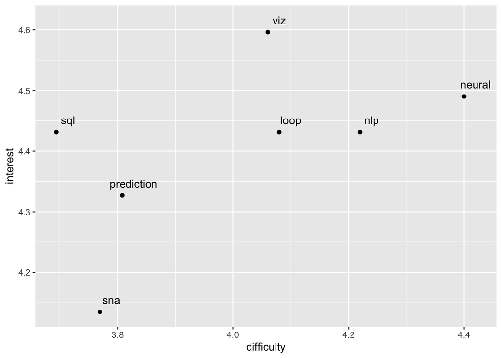

```r
p <- ggplot(difficulty_interest, aes(difficulty,
                                     interest,
                                     label = rownames(difficulty_interest))) +
  geom_point() +
  geom_text(nudge_x = 0.02, nudge_y = 0.02)
p
```

### Following the same idea as KNN to measure the distance of any given point to the rest of the points in the dataset

#### First, select the first instance as the source item

```r
x <- difficulty_interest[1,]
x
```

```
##            difficulty interest
## prediction   3.807692 4.326923
```

#### Creating a data frame with 7 rows (same names as “difficulty_interest”) all filled with NAs.

```r
distance <- data.frame(d = rep(NA, 7), row.names = row.names(difficulty_interest))
```

#### Loop through every row in difficulty_interest and measure the distance.

```r
for (i in 1:nrow(difficulty_interest)) {
  y <- difficulty_interest[i,] #pick one of the rows as the target item
  d <- dist(rbind(x, y)) # measure the euclidean distance (by default) and assign to d
  distance[i, 1] <- d # insert the calculated distance to the distance data frame
}

arrange(distance, d)
```

```
##                    d
## prediction 0.0000000
## sql        0.1544781
## sna        0.1961161
## loop       0.2916525
## viz        0.3689775
## nlp        0.4253320
## neural     0.6143993
```

# USING COSINE SIMILARITY TO MEASURE DISTANCE —————————–

## install.packages(“lsa”)

```r
library(lsa)
## Converting the difficulty interest dataframe to matrix format and then transposing it
di <- difficulty_interest %>%
  as.matrix() %>%
  t()
```

## Generating the cosine similarity values as a new matrix.

```r
di_sim <- cosine(di)
```

## We want to remove the matrix generated above because the items are similar to themselves in the diagonal

```r
diag(di_sim) <- NA
```

## Quick query to find out what items are similar to any given item.

```r
item <- "viz" # a dataset item name
```

## Returns the 4 most similar items to the item defined above.

```r
head(rownames(di_sim[order(di_sim[item,], decreasing = TRUE),]), n = 4)
```

```
## [1] "prediction" "sna"        "loop"       "sql"
```

### COLLABORATIVE FILTER —————————————————-

```r
interest <- column_to_rownames(interest, var = "id") #move the id to row names
interestMatrix <- interest %>%
  as.matrix() %>% t()
interestSim <- cosine(interestMatrix)
diag(interestSim) <- NA
person <- "s5"
head(rownames(interestSim[order(interestSim[person,], decreasing = TRUE),]))
```

```
## [1] "s46" "s47" "s2"  "s6"  "s12" "s13"
```